# AirBnB

Luc Wilson

2024-05-21

## Introduction

This document seeks to answer the prediction question:

#### How well can you predict letting rates on AirBNB?

The goal of this investigation therefore is to construct a robust predictive model with minimal error and maximal predictive accuracy.

This is done by:

- Firstly, cleaning the data and one-hot encoding some categorical variables so they may be used in a numerical model. This was a critical stage in answering this question. By avoiding removing too many columns and rows there are more data points for the model to use.
- Secondly, investigating variable importances and iterating model specifications to optimise a random forest model. Intially a model is trained with the Air_BnB data alone and then it is uspplemented with POI data. This gives an approximation of how central the Air_BnB is to towns and therefore introduces a spatial component to the analysis greater than just longitude and latitude. A random forest model was selected to answer this question because they are able to deal with high dimensional, non-linear data, like the data we have here.
- Thirdly, to verify and contextualise the success of the model, an XGBoost model is fitted using the same variables.

```r
# loading required libraries
library(mltools)
library(tidyverse)
library(caret)
library(data.table)
library(sf)
library(parallel)
library(doParallel)
```

## Preprocessing

Here, only the relevant columns were read into the R environment to save computation. The dropped columns were fro a variety of reasons: they were either irrelevant to the question, contained repeated or very similar information as other variables, or the columns were mostly (or entirely) empty.

the dropped columns were: - url (irrelevant) - scrape_id (irrelevant) - last_scraped (irrelevant) - source (irrelevant) - picture_url (irrelevant) - host_url (irrelevant) - host_thumbnail_url (irrelevant) - host_picture_url (irrelevant) - neighbourhood_group_cleansed (empty) - bathrooms (empty) - bedrooms (empty) - amenities (empty) - minimum_nights (repeated information) - maximum_nights (repeated information) - minimum_minimum_nights (repeated information) - maximum_minimum_nights (repeated information) - minimum_maximum_nights (repeated information) - maximum_maximum_nights(repeated information) - calendar_updated (empty) - calendar_last_scraped (irrelevant) - license (irrelevant)

```r
# C:/Users/lewil/OneDrive - University of Bristol/Msc Geographic Data Science & Spatial Analytics/Machine Learning/Final/AirBnB/
Air_BnB = read_csv("airbnbs.csv",
                   trim_ws = TRUE,                   # removing leading and trailing spaces
                   col_select = c("price",           # only reading in relevant columns
                                  "host_since",
                                  "host_location",
                                  "host_about",
                                  "host_response_time",
                                  "host_response_rate",
                                  "host_acceptance_rate",
                                  "host_is_superhost",
                                  "host_listings_count",
                                  "host_total_listings_count",
                                  "host_verifications",
                                  "host_has_profile_pic",
                                  "host_identity_verified",
                                  "neighbourhood",
                                  "neighbourhood_cleansed",
                                  "latitude",
                                  "longitude",
                                  "property_type",
                                  "room_type",
                                  "accommodates",
                                  "bathrooms_text",
                                  "beds",
                                  "minimum_nights_avg_ntm",
                                  "maximum_nights_avg_ntm",
                                  "has_availability",
                                  "availability_30",
                                  "availability_60",
                                  "availability_90",
                                  "availability_365",
                                  "number_of_reviews",
                                  "number_of_reviews_ltm",
                                  "number_of_reviews_l30d",
                                  "last_review",
                                  "first_review",
                                  "review_scores_rating",
                                  "review_scores_cleanliness",
                                  "review_scores_checkin",
                                  "review_scores_communication",
                                  "review_scores_location",
                                  "review_scores_value",
                                  "instant_bookable",
                                  "calculated_host_listings_count",
                                  "reviews_per_month")
                   )

# since price is the dependent variable, droppping any rows without price
Air_BnB = Air_BnB %>%
  filter(!is.na(price))


# ensuring dates are formatted correctly
Air_BnB <- Air_BnB %>%
  mutate(
    host_since = as.Date(host_since, format = "%d/%m/%Y"),
    last_review = as.Date(last_review, format = "%d/%m/%Y"),
    first_review = as.Date(first_review, format = "%d/%m/%Y")
  )
```

```r
# converting host_since to days instead of date
last_scraped = as.Date("2023-12-25")

Air_BnB <- Air_BnB %>%
  mutate(
    host_since_days = as.numeric(difftime(host_since, last_scraped, units = "days")*-1) # multiplying by minus to make positive
  )
# droppping host_since
Air_BnB <- Air_BnB %>%
  select(-host_since)
```

```r
# one-hot encoding host_location

# first categorising host_location as Bristol, UK, Not_UK, unspecified
Air_BnB <- Air_BnB %>%
  mutate(
    host_location_cat = case_when(
      str_detect(host_location, regex("Bristol", ignore_case = TRUE)) ~ "Bristol",
      str_detect(host_location, regex("England|United Kingdom|UK", ignore_case = TRUE)) &
        !str_detect(host_location, regex("Bristol", ignore_case = TRUE)) ~ "UK",
      !is.na(host_location) ~ "Not_UK",
      is.na(host_location) ~ "unspecified"
    )
  ) %>%
  mutate(host_location_cat = factor(host_location_cat))

# making one-hot encoded cols
one_hot <- model.matrix(~ 0 + host_location_cat, data = Air_BnB)

# simplifying column names (they are unusual without this)
colnames(one_hot) <- make.names(colnames(one_hot))

# binding new cols to Air_BnB
Air_BnB <- cbind(Air_BnB, one_hot)

# dropping redundant columns
Air_BnB <- Air_BnB %>%
  select(-host_location, -host_location_cat)
```

```r
# creating word count column for host_about
Air_BnB <- Air_BnB %>%
  mutate(
    host_about_wrdcnt = str_count(host_about, "\\S+")
  )%>%
  replace_na(list(host_about_wrdcnt = 0))

# droppping host_about
Air_BnB <- Air_BnB %>%
  select(-host_about)
```

```r
# converting host_response_rate and host_acceptance_rate to decimals
Air_BnB <- Air_BnB %>%
  mutate(
    host_response_rate = str_remove(host_response_rate, "%") %>%
                          as.numeric() / 100,
    host_acceptance_rate = str_remove(host_acceptance_rate, "%") %>%
                           as.numeric() / 100
  )
```

```r
# converting host_is_superhost, host_identity_verified, host_has_profile_pic, neighbourhood, has_availability, instant_bookable to one-hot-encoded
Air_BnB <- Air_BnB %>%
  mutate(
    host_is_superhost = as.integer(host_is_superhost),
    host_identity_verified = as.integer(host_identity_verified),
    host_has_profile_pic = as.integer(host_has_profile_pic),
    has_availability = as.integer(has_availability),
    instant_bookable = as.integer(instant_bookable),
    neighbourhood_stated  = as.integer(!is.na(neighbourhood))
  )

# dropping neighbourhood (still got neighbourhood_cleansed)
Air_BnB <- Air_BnB %>%
  select(-neighbourhood)
```

```r
# changing host_verifications to only be how many verifications are provided
Air_BnB <- Air_BnB %>%
  mutate(
    host_verifications = str_count(host_verifications, "\\S+")
  )%>%
  replace_na(list(host_about_wrdcnt = 0))
```

```r
# removing dollar signs in price
Air_BnB = Air_BnB %>%
  mutate(price = as.numeric(gsub("\\$", "", price)))%>%
  filter(!is.na(price)) # droppping any rows with NAs
```

```r
# dropping bathromm NAs
Air_BnB = Air_BnB %>%
  filter(!is.na(bathrooms_text))
```

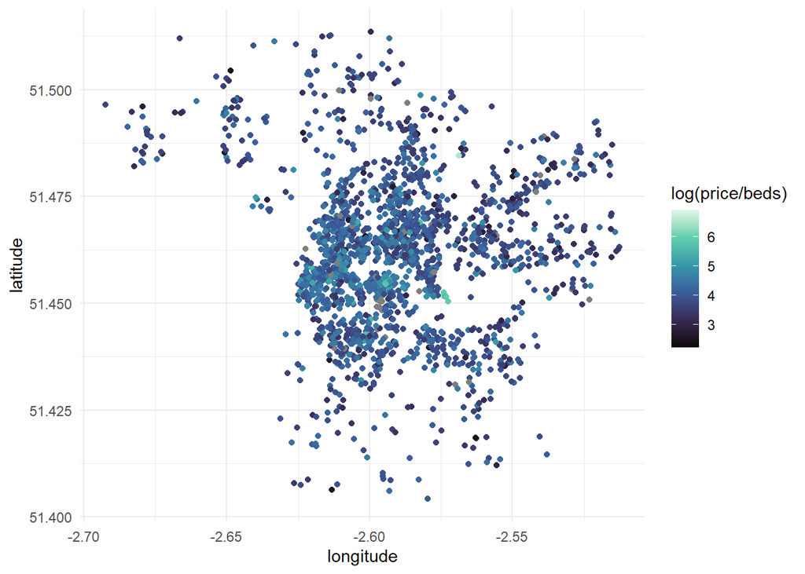

```r
# plotting points (colouring by price per bed) to get overview of spatial dependencies in price per bed
ggplot(data = Air_BnB,
       aes(x = longitude,
           y = latitude,
           color = log(price/beds))) + # scaling to view better
  geom_point() +
   scale_color_viridis_c(option = "G") + # to make it easier to see
  theme_minimal()
```

```r
# clearly some spatial dependancy in pricing.
```

Clearly proximity to city centre affects price. I will use POI density and Air_BnB density to accomodate for this.

```r
dim(Air_BnB)
```

```
## [1] 2159   46
```

```r
# looking at how many NAs per column
na_counts = sapply(Air_BnB, function(x) sum(is.na(x)))
na_counts[na_counts > 0] # only showing columns with NAs
```

```
##          host_response_rate        host_acceptance_rate
##                         240                         116
##           host_is_superhost                        beds
##                           2                          48
##                 last_review                first_review
##                         278                         278
##        review_scores_rating   review_scores_cleanliness
##                         278                         279
##       review_scores_checkin review_scores_communication
##                         279                         279
##      review_scores_location         review_scores_value
##                         279                         279
##           reviews_per_month
##                         278
```

```r
# dealing with NAs

# where host_response_rate is NA they most likely havent had the chance to reply therefore setting to the median response_rate
Air_BnB$host_response_rate[is.na(Air_BnB$host_response_rate)] = median(Air_BnB$host_response_rate, na.rm = TRUE)

# where host_acceptance_rate is NA this means the host has never accepted a booking therefore the price is theoretical - removing these rows
Air_BnB = Air_BnB %>%
  filter(!is.na(host_acceptance_rate))

# where host_is_superhost is NA setting not NA
Air_BnB$host_is_superhost[is.na(Air_BnB$host_is_superhost)] = 0
```

```r
# splitting bathrooms_text into two columns no_baths and is_shared (I am assuming when it is unspecified it is private)

# dropping NA bathrooms_text and dropping
Air_BnB = Air_BnB %>%
  filter(!is.na(bathrooms_text))


Air_BnB <- Air_BnB %>%
  separate(bathrooms_text, into = c("no_baths", "is_shared"), sep = " ", remove = FALSE, extra = "merge") %>%
  mutate(no_baths = as.numeric(no_baths),            # making no_baths numeric
         is_shared = as.integer(grepl("shared", is_shared, ignore.case = TRUE))) # if shared then true, setting as 1
# else set to 0
Air_BnB$is_shared[is.na(Air_BnB$is_shared)] = 0

# dropping NA no_baths
Air_BnB = Air_BnB %>%
  filter(!is.na(no_baths))

# dropping original column
Air_BnB = Air_BnB %>%
  select(-bathrooms_text)
```

```r
# checking if / how many places are listed with 0 bathrooms
sum(Air_BnB$no_baths == 0)
```

```
## [1] 3
```

```r
# there are only three, this is likely a mistake but but it is not impossible there are some places without bathrooms so leaving them in
```

```r
# dropping rows that have no reviews
Air_BnB = Air_BnB %>%
  filter(!is.na(first_review))
```

```r
# Removing NA beds
Air_BnB = Air_BnB %>%
  filter(!is.na(beds))
```

```r
# removing NA review_scores_cleanliness
Air_BnB = Air_BnB %>%
  filter(!is.na(review_scores_cleanliness))
```

```r
# accommodates of 16 is actually 16+ so seeing how many there are - maybe remove
sum(Air_BnB$accommodates == 16)
```

```
## [1] 7
```

```r
sum(Air_BnB$accommodates == 15)
```

```
## [1] 1
```

```r
sum(Air_BnB$accommodates == 14)
```

```
## [1] 2
```

```r
sum(Air_BnB$accommodates == 13)
```

```
## [1] 3
```

```r
sum(Air_BnB$accommodates == 12)
```

```
## [1] 7
```

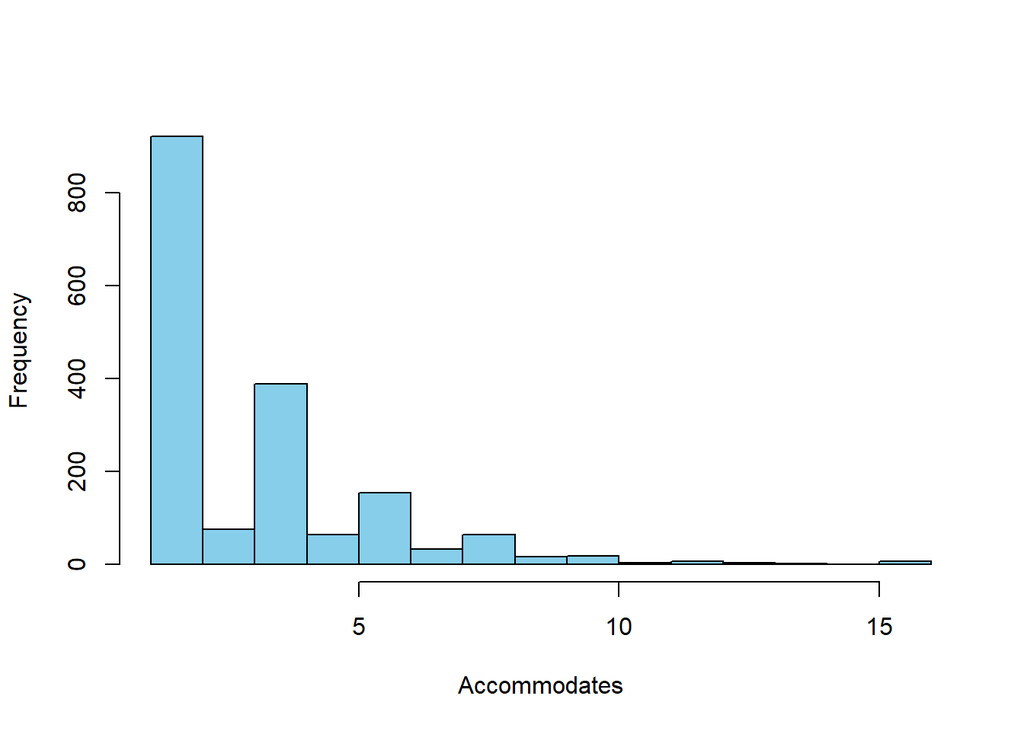

```r
# can see 16 occurring 7 times is false

# plotting histogram
hist(Air_BnB$accommodates,
     main = "",
     xlab = "Accommodates",
     ylab = "Frequency",
     col = "skyblue",
     border = "black")
```

```r
# to mitigate effect of 16s, randomly assigning value between 16 and 25
Air_BnB$accommodates <- ifelse(Air_BnB$accommodates == 16,
                                sample(16:25, sum(Air_BnB$accommodates == 16), replace = TRUE),
                                Air_BnB$accommodates)
```

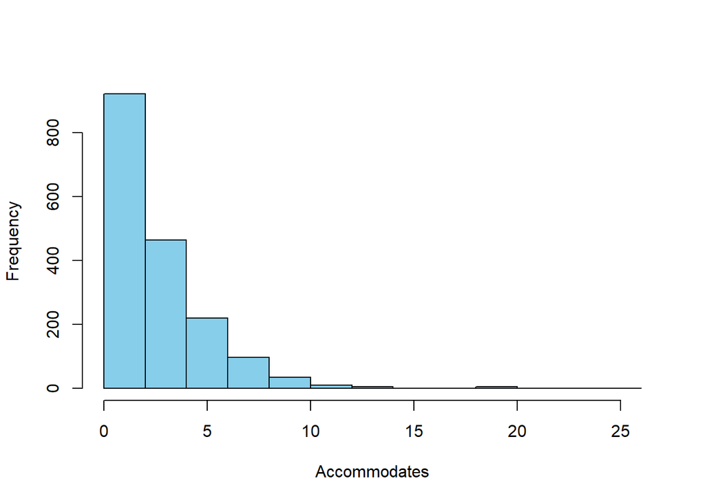

```r
# re-plotting histogram
hist(Air_BnB$accommodates,
     main = "",
     xlab = "Accommodates",
     ylab = "Frequency",
     col = "skyblue",
     border = "black")
```

```r
# looks better - no artificial re-rise
```

```r
# rechecking dimensions
dim(Air_BnB)
```

```
## [1] 1758   47
```

```r
# rechecking NAs
na_counts = sapply(Air_BnB, function(x) sum(is.na(x)))
na_counts[na_counts > 0]
```

```
## named integer(0)
```

```r
# now no NAs
```

```r
# checking how many unique values there are in property_type
length(unique(Air_BnB$room_type))
```

```
## [1] 4
```

```r
# few enough to one-hot encode
```

```r
# one hot encode room_type

# Perform one-hot encoding on room_type
room_type_one_hot <- as.data.frame(model.matrix(~ 0 + Air_BnB$room_type))

# Bind the one-hot encoded columns and the "other" column to the original data frame
Air_BnB <- cbind(Air_BnB, room_type_one_hot)

# drop original
Air_BnB = Air_BnB %>%
  select(-property_type)

# drop original
Air_BnB = Air_BnB %>%
  select(-room_type)
```

```r
# checking how many categories there are for host_response_time:

length(unique(Air_BnB$host_response_time))+1 # adding 1 to include null
```

```
## [1] 6
```

```r
# one-hot encoding host_response_time

# if NA setting to "no_responses"
Air_BnB$host_response_time[is.na(Air_BnB$host_response_time)] <- "no_responses"

# one-hot encoding
response_time_one_hot <- as.data.frame(model.matrix(~ 0 + Air_BnB$host_response_time))

# Bind the one-hot encoded columns and the "other" column to the original data frame
Air_BnB <- cbind(Air_BnB, response_time_one_hot)

# drop original
Air_BnB = Air_BnB %>%
  select(-host_response_time)
```

```r
# convert last_review since data set was scraped

Air_BnB <- Air_BnB %>%
  mutate(
    last_review_days = as.numeric(difftime(last_review, last_scraped, units = "days")*-1) # multiplying by minus to make positive
  )
# droppping host_since
Air_BnB <- Air_BnB %>%
  select(-last_review)

# convert first_review to how many days after the first listing minus the minimum days (measure of how quickly someone booked in with them)
Air_BnB <- Air_BnB %>%
  mutate(
    first_review_days = as.numeric(difftime(first_review, host_since_days - minimum_nights_avg_ntm, units = "days"))
  )
# droppping host_since
Air_BnB <- Air_BnB %>%
  select(-first_review)
```

```r
# training model for optimal MSE to find variable importances (treating lat and long as variables for now)
set.seed(1234) # same seed

# selecting variables to include
all_vars <- names(Air_BnB)

# excluding unwanted variables
excluded_vars <- c("price", "neighbourhood_cleansed")
vars_to_include <- all_vars[!all_vars %in% excluded_vars]

# cleaning variables
cleaned_vars <- sapply(vars_to_include, function(x) {
  x <- gsub("/", ".", x)
  x <- gsub(" ", "_", x)
  x <- gsub("$", "", x)
  x <- gsub("\\$", "", x)
  return(x)
})

# making same changes to Air_BnB
cleaned_colnames <- sapply(all_vars, function(col_name) {
  col_name <- gsub("/", ".", col_name)
  col_name <- gsub(" ", "_", col_name)
  col_name <- gsub("$", "", col_name)
  col_name <- gsub("\\$", "", col_name)
  return(col_name)
})

# replacing column names in Air_BnB dataset with cleaned names
names(Air_BnB) <- cleaned_colnames

all_vars <- names(Air_BnB)

# excluding select variables
excluded_vars <- c("price", "neighbourhood_cleansed")

vars_to_include <- all_vars[!all_vars %in% excluded_vars]
length(vars_to_include)
```

```
## [1] 51
```

```r
# writing forumla string
formula_string <- paste("price~", paste(vars_to_include, collapse = " + "))

# Converting to formula
formula <- as.formula(formula_string)
```

```r
# looking for pairwise correlation
Air_BnB_numeric = Air_BnB %>%
  mutate_all(as.numeric)
```

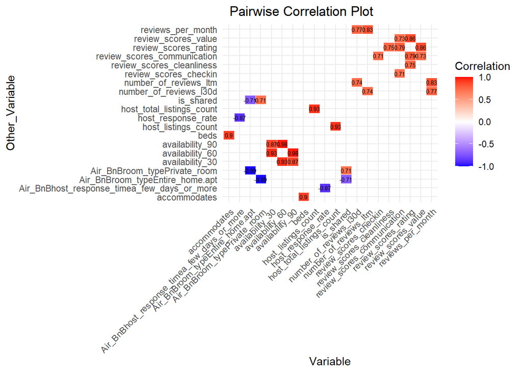

```r
correlation_matrix <- as.data.frame(cor(Air_BnB_numeric, use = "pairwise.complete.obs"))

correlation_df <- correlation_matrix %>%
  as.data.frame() %>%
  rownames_to_column("Variable") %>%
  pivot_longer(-Variable, names_to = "Other_Variable", values_to = "Correlation")

filtered_correlation_df <- correlation_df %>%
  filter(abs(Correlation) > 0.7 & Variable != Other_Variable) # only showing most correlated because there are lots of variables and the plot becomes messy

ggplot(filtered_correlation_df, aes(x = Variable, y = Other_Variable, fill = Correlation)) +
  geom_tile(color = "white") +
  geom_text(aes(label = ifelse(Variable == Other_Variable, "", round(Correlation, 2))),
            color = "black",# only showing once
            size = 2) + # changing the size of the numers on the plot
  scale_fill_gradient2(low = "blue", high = "red", mid = "white",
                       midpoint = 0,
                       limit = c(-1, 1),
                       name = "Correlation") +
  theme_minimal() +
  labs(title = "Pairwise Correlation Plot") +
  theme(axis.text.x = element_text(angle = 45, hjust = 1),
        plot.title = element_text(hjust = 0.1))
```

## Training Random Forest Model

Note: All training models have been commented out but their result summaries have been printed. This is to save computation in knitting the document.

```r
set.seed(1234)

# nested resampling to utilise cross validation and bootstrapping. Intention is to give most robust model

# ensuring parallel processing is enabled
registerDoParallel(parallel::detectCores())

# setting train controls
train_control <- trainControl(
  method = "boot",          # bootstrapping
  number = 10,             # number of resamples
  allowParallel = TRUE
)

nested_train_control <- trainControl(
  method = "cv",          # using cross validation
  number = 5,             # number of folds
  allowParallel = TRUE
)

# running model
rf_model_mse <- train(
    formula,
  data = Air_BnB, # because of cross validation, using whole data set
  method = "rf",            # random forest
  metric = "RMSE",          # optimising for RMSE (root mean squared error)
  trControl = train_control, # Training control
  search_control = nested_train_control, # nested cross validation control
  allowParallel = TRUE
)

MSE_rf_model = rf_model_mse$finalModel # retrieving lowest RMSE model

#  randomForest(x = x, y = y, mtry = param$mtry, search_control = ..1,      allowParallel = TRUE)
#                Type of random forest: regression
#                      Number of trees: 500
# No. of variables tried at each split: 26
#
#           Mean of squared residuals: 4181.988
#                     % Var explained: 60.7
```

```r
# checking variable importance
importances = varImp(rf_model_mse)
print(importances)
```

```
## rf variable importance
##
##   only 20 most important variables shown (out of 51)
##
##                                 Overall
## accommodates                    100.000
## beds                             40.814
## no_baths                         27.405
## first_review_days                11.781
## Air_BnBroom_typeEntire_home.apt  11.342
## latitude                          9.998
## longitude                         9.979
## host_since_days                   9.946
## last_review_days                  9.540
## Air_BnBroom_typePrivate_room      8.339
## number_of_reviews                 8.226
## availability_365                  6.864
## review_scores_rating              5.784
## review_scores_location            5.642
## reviews_per_month                 5.616
## host_total_listings_count         5.207
## review_scores_value               4.832
## minimum_nights_avg_ntm            4.462
## calculated_host_listings_count    3.878
## review_scores_cleanliness         3.848
```

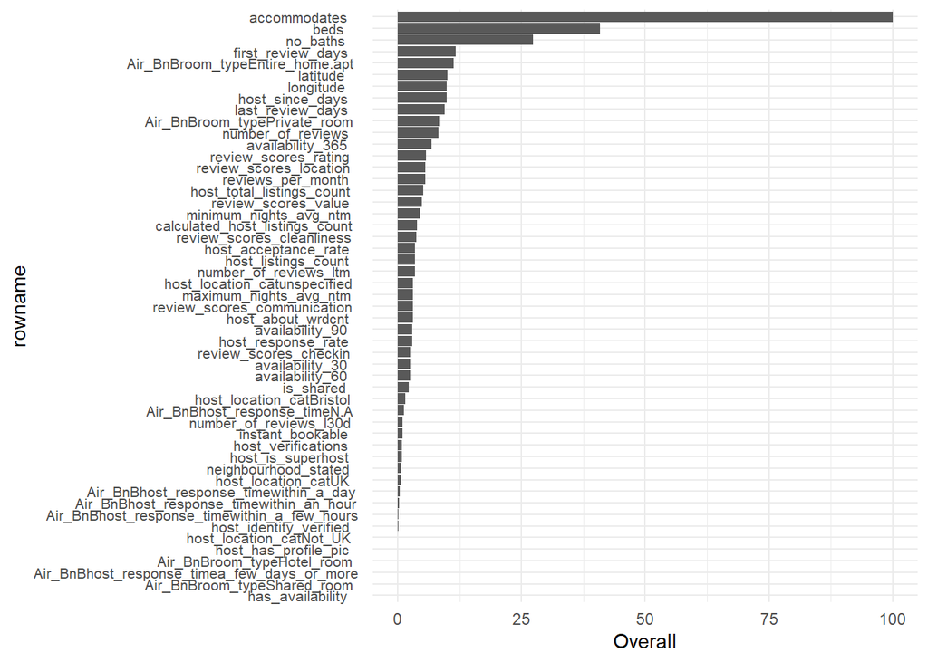

```r
# to see more than 20
varImp(rf_model_mse)$importance %>%
  as.data.frame() %>%
  rownames_to_column() %>%
  arrange(Overall) %>%
  mutate(rowname = forcats::fct_inorder(rowname )) %>%
  ggplot()+
    geom_col(aes(x = rowname, y = Overall))+
    coord_flip()+
    theme_minimal() +
  theme(axis.text.y = element_text(size = 8, hjust = 0.95, margin = margin(r = 5)))
```

```r
# preparing to rerun with least important variables removed
least_important_vars <- varImp(rf_model_mse)$importance %>%
  as.data.frame() %>%
  rownames_to_column() %>%
  filter(Overall < 1) %>%
  pull(rowname)

excluded_vars <- c("price", "neighbourhood_cleansed", least_important_vars)

vars_to_include <- all_vars[!all_vars %in% excluded_vars]
length(vars_to_include)
```

```
## [1] 37
```

```r
# writing forumla as string
formula_string <- paste("price~", paste(vars_to_include, collapse = " + "))

# Converting to formula
formula <- as.formula(formula_string)
```

```r
# rerunning with 15/54 least important variables removed
set.seed(1234)

rf_model_mse1 <- train(
    formula,
  data = Air_BnB,
  method = "rf",            # Random forest
  metric = "RMSE",          # Optimising for RMSE (root mean squared error)
  #tuneGrid = tune_grid,     # Hyperparameter grid
  trControl = train_control, # Training control
  search_control = nested_train_control, # nested cross validation control
  allowParallel = TRUE
)

MSE_rf_model1 = rf_model_mse1$finalModel
#                Type of random forest: regression
#                      Number of trees: 500
# No. of variables tried at each split: 19
#
#           Mean of squared residuals: 4135.504
#                     % Var explained: 61.13
```

```r
# reading in POI data to supplement analysis
# data from https://download.geofabrik.de/europe/united-kingdom/england.html
pois = st_read("Bristoldat/gis_osm_pois_a_free_1.shp")
# inspecting
dim(pois)
```

```
## [1] 5455    5
```

```r
length(unique(pois$fclass))
```

```
## [1] 106
```

```r
# converting multipoligons to point geometries
POIs = pois %>%
  mutate(geometry = st_centroid(geometry))
```

```r
# creating POI density score

# making sure Air_BnB_sf and POIs have the same CRS
Air_BnB_sf <- st_as_sf(Air_BnB, coords = c("longitude", "latitude"), crs = 4326)
Air_BnB_sf <- st_transform(Air_BnB_sf, crs = 3857)

POIs = st_transform(POIs, crs = 3857)

# adding latitude and longitude back in as variables
Air_BnB_sf = cbind(Air_BnB_sf, Air_BnB$latitude, Air_BnB$longitude)
```

```r
# calculating basic POI density score for Air_BnB_sf

# setting 400m radius - this was determined by repeating with 300, 350, 400, 450, 500, and 600
radius = 400

# making buffers to determine how POIs are counted
Air_BnB_buffers <- st_buffer(Air_BnB_sf, dist = radius)

# Count POIs within each buffer
Air_BnB_sf$POIdensity_score <- sapply(st_geometry(Air_BnB_buffers), function(buffer) {
  sum(st_intersects(buffer, POIs, sparse = FALSE))
})

head(Air_BnB_sf$POIdensity_score)
```

```
## [1] 12 21 66  5 10 35
```

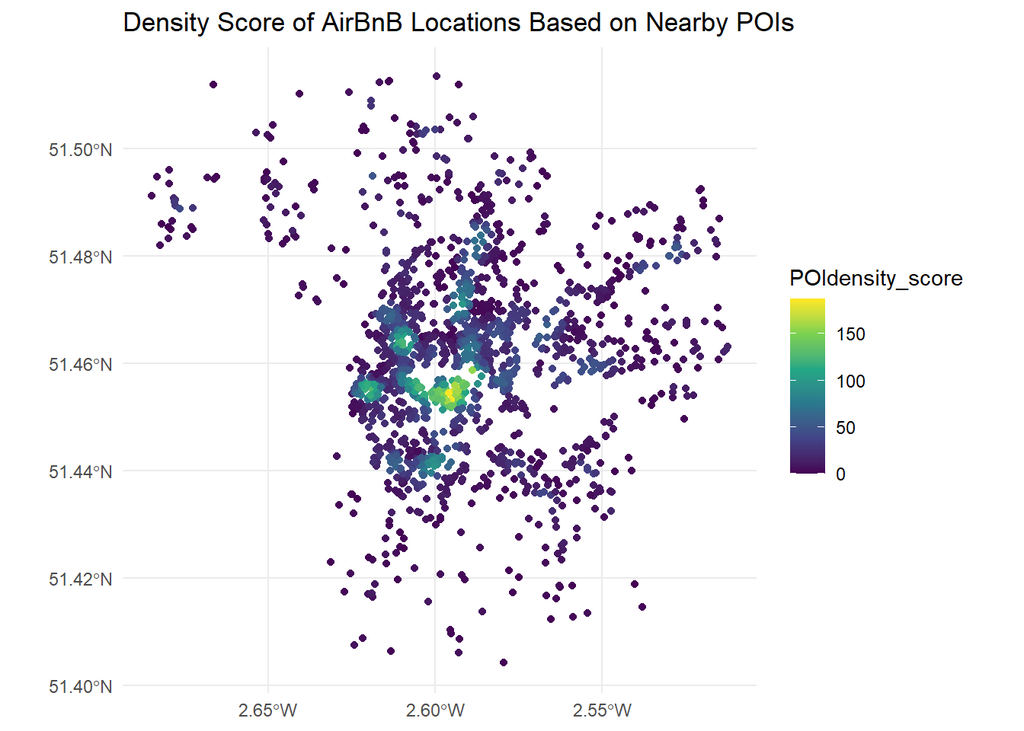

```r
# visualising
ggplot() +
  geom_sf(data = Air_BnB_sf, aes(color = POIdensity_score)) +
  scale_color_viridis_c() +
  theme_minimal() +
  labs(title = "Density Score of AirBnB Locations Based on Nearby POIs")
```

```r
# preparing to rerun with least important variables removed
set.seed(1234)

all_vars <- names(Air_BnB_sf)

least_important_vars <- varImp(rf_model_mse)$importance %>%
  as.data.frame() %>%
  rownames_to_column() %>%
  filter(Overall < 1) %>%
  pull(rowname)

excluded_vars <- c("price" ,"neighbourhood_cleansed",
                   least_important_vars,
                  # "latitude",
                 #  "longitude", # removing latitude and logitude now
                   "geometry"
                 )
vars_to_include <- all_vars[!all_vars %in% excluded_vars]
length(vars_to_include)
```

```
## [1] 38
```

```r
# writing forumla as string
formula_string <- paste("price~", paste(vars_to_include, collapse = " + "))

# Converting to formula
formula <- as.formula(formula_string)
```

```r
# rerunning with 15/54 least important variables removed
set.seed(1234)

rf_model_mse2 <- train(
    formula,
  data = Air_BnB_sf,
  method = "rf",            # Random forest
  metric = "RMSE",          # Optimising for RMSE (root mean squared error)
  #tuneGrid = tune_grid,     # Hyperparameter grid
  trControl = train_control, # Training control
  search_control = nested_train_control, # nested cross validation control
  allowParallel = TRUE
)

MSE_rf_model2 = rf_model_mse2$finalModel
# #                Type of random forest: regression
# #                      Number of trees: 500
# # No. of variables tried at each split: 20
# #
# #           Mean of squared residuals: 4202.624
# #                     % Var explained: 60.5
```

```r
#rechekcing variable importances
importances2 = varImp(rf_model_mse2)
print(importances2)
```

```
## rf variable importance
##
##   only 20 most important variables shown (out of 38)
##
##                                 Overall
## accommodates                    100.000
## beds                             33.897
## POIdensity_score                 24.376
## no_baths                         22.442
## Air_BnBroom_typeEntire_home.apt  10.830
## first_review_days                 9.555
## Air_BnB.longitude                 8.824
## host_since_days                   8.185
## Air_BnB.latitude                  7.956
## Air_BnBroom_typePrivate_room      7.595
## last_review_days                  7.470
## availability_365                  5.514
## number_of_reviews                 5.308
## review_scores_location            4.802
## reviews_per_month                 4.149
## host_total_listings_count         3.883
## minimum_nights_avg_ntm            2.958
## host_acceptance_rate              2.723
## calculated_host_listings_count    2.654
## review_scores_rating              2.563
```

```r
# # rerun model with AIR_BnB densities (represents supply of Air BnBs - important economic control)
radius1 = 400

Air_BnB_buffers <- st_buffer(Air_BnB_sf, dist = radius1)

# Count other AirBnB points within each buffer
Air_BnB_sf$AirBnBdensity_score <- sapply(1:nrow(Air_BnB_sf), function(i) {
  # Exclude the current AirBnB point from consideration
  other_points <- Air_BnB_sf[-i, ]

  # Get the buffer geometry
  buffer <- st_geometry(Air_BnB_buffers)[i]

  # Check if any other AirBnB points are within the buffer
  count <- sum(st_intersects(buffer, other_points, sparse = FALSE))

  # Return the count
  return(count)
})

head(Air_BnB_sf$AirBnBdensity_score)
```

```
## [1]  6 16 26  9  4 13
```

```r
# repeating with AirBnBdensity_score
all_vars <- names(Air_BnB_sf)

least_important_vars <- varImp(rf_model_mse2)$importance %>%
  as.data.frame() %>%
  rownames_to_column() %>%
  filter(Overall < 1) %>%
  pull(rowname)

excluded_vars <- c("price", "neighbourhood_cleansed",
                   least_important_vars,
                  # "latitude",
                 #  "longitude", # removing latitude and logitude now
                   "geometry"
                 )
vars_to_include <- all_vars[!all_vars %in% excluded_vars]
length(vars_to_include)
```

```
## [1] 49
```

```r
# writing forumla as string
formula_string <- paste("price~", paste(vars_to_include, collapse = " + "))

# Converting to formula
formula <- as.formula(formula_string)
```

```r
set.seed(1234)

rf_model_mse3 <- train(
    formula,
  data = Air_BnB_sf,
  method = "rf",            # Random forest
  metric = "RMSE",          # Optimising for RMSE (root mean squared error)
  #tuneGrid = tune_grid,     # Hyperparameter grid
  trControl = train_control, # Training control
  search_control = nested_train_control, # nested cross validation control
  allowParallel = TRUE
)

MSE_rf_model3 = rf_model_mse3$finalModel
MSE_rf_model3
```

```
##
## Call:
##  randomForest(x = x, y = y, mtry = param$mtry, search_control = ..1,      allowParallel = TRUE)
##                Type of random forest: regression
##                      Number of trees: 500
## No. of variables tried at each split: 25
##
##           Mean of squared residuals: 4147.278
##                     % Var explained: 61.02
```

```r
#rechekcing variable importances
importances3 = varImp(rf_model_mse3)
print(importances3)
```

```
## rf variable importance
##
##   only 20 most important variables shown (out of 49)
##
##                                 Overall
## accommodates                    100.000
## beds                             40.573
## POIdensity_score                 24.108
## no_baths                         23.557
## Air_BnBroom_typeEntire_home.apt  11.990
## Air_BnB.longitude                 9.670
## first_review_days                 9.324
## Air_BnBroom_typePrivate_room      9.069
## host_since_days                   8.941
## last_review_days                  8.792
## Air_BnB.latitude                  7.958
## availability_365                  6.566
## number_of_reviews                 6.119
## AirBnBdensity_score               5.761
## review_scores_location            5.124
## reviews_per_month                 4.920
## host_total_listings_count         4.828
## minimum_nights_avg_ntm            3.576
## host_acceptance_rate              3.535
## number_of_reviews_ltm             3.260
```

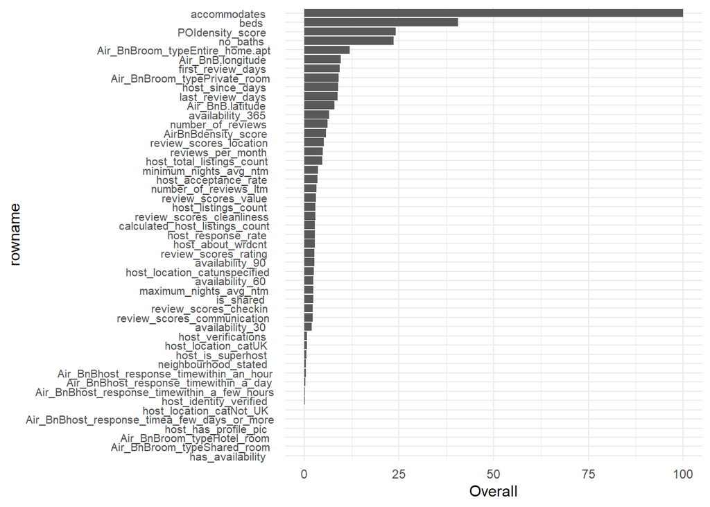

```r
# regreaphing importances
varImp(rf_model_mse3)$importance %>%
  as.data.frame() %>%
  rownames_to_column() %>%
  arrange(Overall) %>%
  mutate(rowname = forcats::fct_inorder(rowname )) %>%
  ggplot()+
    geom_col(aes(x = rowname, y = Overall))+
    coord_flip()+
    theme_minimal() +
  theme(axis.text.y = element_text(size = 8, hjust = 0.95, margin = margin(r = 5)))
```

```r
# removing least important variables
all_vars <- vars_to_include # updated from above to carry forward unimportant variables

least_important_vars <- varImp(rf_model_mse3)$importance %>%
  as.data.frame() %>%
  rownames_to_column() %>%
  filter(Overall < 1) %>%
  pull(rowname)

excluded_vars <- c("price", "neighbourhood_cleansed",
                   least_important_vars,
                  # "latitude",
                 #  "longitude", # removing latitude and logitude now
                   "geometry"
                 )
vars_to_include <- all_vars[!all_vars %in% excluded_vars]
length(vars_to_include)
```

```
## [1] 35
```

```r
# writing forumla as string
formula_string <- paste("price~", paste(vars_to_include, collapse = " + "))

# Converting to formula
formula <- as.formula(formula_string)
```

```r
set.seed(1234)

# rerunning with more removed
rf_model_mse4 <- train(
    formula,
  data = Air_BnB_sf,
  method = "rf",            # Random forest
  metric = "RMSE",          # Optimising for RMSE (root mean squared error)
  #tuneGrid = tune_grid,     # Hyperparameter grid
  trControl = train_control, # Training control
  search_control = nested_train_control, # nested cross validation control
  allowParallel = TRUE
)

MSE_rf_model4 = rf_model_mse4$finalModel
MSE_rf_model4
```

```
##
## Call:
##  randomForest(x = x, y = y, mtry = param$mtry, search_control = ..1,      allowParallel = TRUE)
##                Type of random forest: regression
##                      Number of trees: 500
## No. of variables tried at each split: 18
##
##           Mean of squared residuals: 4160.795
##                     % Var explained: 60.9
```

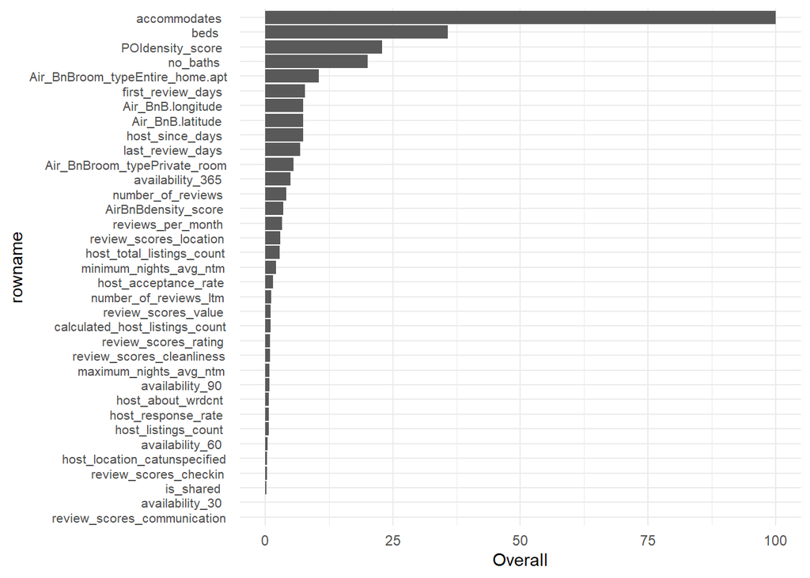

```r
# greaphing new importances
varImp(rf_model_mse4)$importance %>%
  as.data.frame() %>%
  rownames_to_column() %>%
  arrange(Overall) %>%
  mutate(rowname = forcats::fct_inorder(rowname )) %>%
  ggplot()+
    geom_col(aes(x = rowname, y = Overall))+
    coord_flip()+
    theme_minimal() +
  theme(axis.text.y = element_text(size = 8, hjust = 0.95, margin = margin(r = 5)))
```

```r
# final model with all unimportant variables removed
set.seed(1234)

all_vars <- vars_to_include # updated from above to carry forward unimportant variables

least_important_vars <- varImp(rf_model_mse4)$importance %>%
  as.data.frame() %>%
  rownames_to_column() %>%
  filter(Overall < 1) %>%
  pull(rowname)

excluded_vars <- c("price", "neighbourhood_cleansed",
                   least_important_vars,
                  # "latitude",
                 #  "longitude",
                   "geometry"
                 )
vars_to_include <- all_vars[!all_vars %in% excluded_vars]
length(vars_to_include)
```

```
## [1] 22
```

```r
# writing forumla as string
formula_string <- paste("price~", paste(vars_to_include, collapse = " + "))

# Converting to formula
formula <- as.formula(formula_string)


# rerunning with more removed
rf_model_mse5 <- train(
    formula,
  data = Air_BnB_sf,
  method = "rf",            # Random forest
  metric = "RMSE",          # Optimising for RMSE (root mean squared error)
  trControl = train_control, # Training control
  search_control = nested_train_control, # nested cross validation control
  allowParallel = TRUE
)

MSE_rf_model5 = rf_model_mse5$finalModel
MSE_rf_model5
```

```
##
## Call:
##  randomForest(x = x, y = y, mtry = param$mtry, search_control = ..1,      allowParallel = TRUE)
##                Type of random forest: regression
##                      Number of trees: 500
## No. of variables tried at each split: 12
##
##           Mean of squared residuals: 4166.736
##                     % Var explained: 60.84
```

```r
# removing unimportant variables
set.seed(1234)

all_vars <- vars_to_include # updated from above to carry forward unimportant variables

least_important_vars <- varImp(rf_model_mse5)$importance %>%
  as.data.frame() %>%
  rownames_to_column() %>%
  filter(Overall < 1) %>%
  pull(rowname)

excluded_vars <- c("price", "neighbourhood_cleansed",
                   least_important_vars,
                  # "latitude",
                 #  "longitude",
                   "geometry"
                 )
vars_to_include <- all_vars[!all_vars %in% excluded_vars]
length(vars_to_include)
```

```
## [1] 17
```

```r
# writing forumla as string
formula_string <- paste("price~", paste(vars_to_include, collapse = " + "))

formula = as.formula(formula_string)


rf_model_mse6 <- train(
    formula,
  data = Air_BnB_sf,
  method = "rf",            # Random forest
  metric = "RMSE",          # Optimising for RMSE (root mean squared error)
  trControl = train_control, # Training control
  search_control = nested_train_control, # nested cross validation control
  allowParallel = TRUE
)

MSE_rf_model6 = rf_model_mse6$finalModel
MSE_rf_model6
```

```
##
## Call:
##  randomForest(x = x, y = y, mtry = param$mtry, search_control = ..1,      allowParallel = TRUE)
##                Type of random forest: regression
##                      Number of trees: 500
## No. of variables tried at each split: 9
##
##           Mean of squared residuals: 4156.044
##                     % Var explained: 60.94
```

```r
# removing unimportant variables
set.seed(1234)

all_vars <- vars_to_include # updated from above to carry forward unimportant variables

least_important_vars <- varImp(rf_model_mse6)$importance %>%
  as.data.frame() %>%
  rownames_to_column() %>%
  filter(Overall < 1) %>%
  pull(rowname)

excluded_vars <- c("price", "neighbourhood_cleansed",
                   least_important_vars,
                  # "latitude",
                 #  "longitude",
                   "geometry"
                 )
vars_to_include <- all_vars[!all_vars %in% excluded_vars]
length(vars_to_include)
```

```
## [1] 11
```

```r
# writing forumla as string
formula_string <- paste("price~", paste(vars_to_include, collapse = " + "))

# is the contents of updated formula string - saves rerunning prior models
#formula = as.formula(formula_string)
# formula = as.formula("price~ host_total_listings_count + accommodates + no_baths + beds + availability_365 + number_of_reviews + host_since_days + Air_BnBroom_typeEntire_home.apt + Air_BnBroom_typePrivate_room + last_review_days + first_review_days + Air_BnB.latitude + Air_BnB.longitude + POIdensity_score")

rf_model_mse7 <- train(
    formula,
  data = Air_BnB_sf,
  method = "rf",            # Random forest
  metric = "RMSE",          # Optimising for RMSE (root mean squared error)
  trControl = train_control, # Training control
  search_control = nested_train_control, # nested cross validation control
  allowParallel = TRUE
)

MSE_rf_model7 = rf_model_mse7$finalModel
#                Type of random forest: regression
#                      Number of trees: 500
# No. of variables tried at each split: 2
#
#           Mean of squared residuals: 4014.265
#                     % Var explained: 62.27
MSE_rf_model7
```

```
##
## Call:
##  randomForest(x = x, y = y, mtry = param$mtry, search_control = ..1,      allowParallel = TRUE)
##                Type of random forest: regression
##                      Number of trees: 500
## No. of variables tried at each split: 9
##
##           Mean of squared residuals: 4156.044
##                     % Var explained: 60.94
```

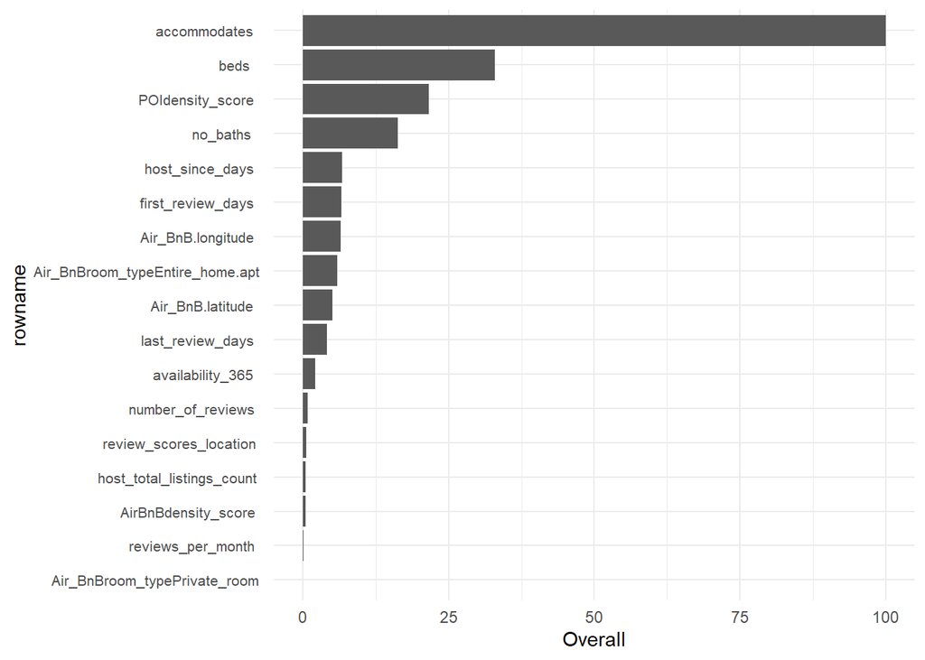

```r
# regraphing variable importances
varImp(rf_model_mse7)$importance %>%
  as.data.frame() %>%
  rownames_to_column() %>%
  arrange(Overall) %>%
  mutate(rowname = forcats::fct_inorder(rowname )) %>%
  ggplot()+
    geom_col(aes(x = rowname, y = Overall))+
    coord_flip()+
    theme_minimal() +
  theme(axis.text.y = element_text(size = 8, hjust = 0.95, margin = margin(r = 5)))
```

```r
# training an XGBoost to compare results

set.seed(1234)

XGB_model <- train(
    formula,
  data = Air_BnB_sf,
  method = "xgbTree",            # XG Boost
  metric = "RMSE",          # Optimising for RMSE (root mean squared error)
  trControl = train_control, # Training control
  search_control = nested_train_control # nested cross validation control
)
```

```
## [15:37:10] WARNING: src/learner.cc:767:
## Parameters: { "search_control" } are not used.
```

```r
# printing results for model with lowest error
XGB_model$results %>%
  filter(RMSE == min(RMSE))
```

```
##   eta max_depth gamma colsample_bytree min_child_weight subsample nrounds
## 1 0.3         3     0              0.6                1         1      50
##       RMSE  Rsquared      MAE   RMSESD RsquaredSD     MAESD
## 1 67.17041 0.5752407 36.32901 5.558716 0.05075102 0.7887351
```

```r
# printing MSE for comparison
(min(XGB_model$results$RMSE))^2
```

```
## [1] 4511.864
```

Random Forest Model Results

- MSE: 4156
- Rsquared: 0.6093

## Limitations and Future Work

Ultimately, the success of these model is limited by variable luxuary in the Air_BnBs. All the attribute data such as beds and location do not account for the luxuray of the appartments. As people we can look at pictures and immediately decide if a bathroom looks “nice” or not but that is not factored into any of the modelling. Location does not account for this at all. Even within the same block of flats, the appearance of bedrooms adn bathrooms can differ entirely. This could only be properly dealt with by utilising a convolutional neural network. This would still be limited by the validation data - the apparent luxury of an appartment is subjective. Either one person would have to grade 1000s of images themselves, firstly into bedroom, bathroom, exterioir, and shared_room and then into luxury rankings. Thsi would, of course, be entirely dependant on this one person’s opinions. Alternatively, a crowd of people could all rank the apparent luxury of the apparetmnets shown in images and then an average could be taken but this would be even harder to implement. The only way i can see this working would be if Air BnB themselves added an apartment luxury ranking option for people to grade and then allow the people who have stayed their to verify whether they agree or not with said ranking in the reviews. - I cannot see this happening however since people can see the photos already and it is only the computer models which cannot understand the luxury of an apartment. If Air BnB were to implement this they could start effectively advising their users if they should increase or decrease their prices or if a location is “good value”.

Distance was useful but there was no measure of travel links. In this sense POI density became a measure of walkable access to amenities. Distance was euclidean but ideally this would have been replaced by distance via road networks. Fortunately, for Bristol there is no tube network which would surely complicate this.